# Certification Data - Summary

2024-02-06

## Data Details and Insights

The following dataset contains past student’ certification status and whether they passed, failed, or their attempt was halted due to Praxis exams.

## Tidying Process

The initial data contained the student’s ID, semesters taken, and notes regarding their certification status. These notes ranged from certified, missing exams, to failed attempts, in total roughly 250 entries distinct entries were recorded. Due to data being older (earliest entry recorded on 2003), it’s probable that it was maintained by various employees throughout the years, thus not having upkept a standardized form.

The notes were then compiled into a set, followed by the frequency per entry before being handed over to another staff member for clarification. Once received, each note was initially marked as passed or failed.

Dataset was updated with new clarifications and the certification_status variable was corrected to a dichotomous/binary format in order to reduce the number of possibilities, clearly stating if the student was certified(1) or not(0).

## Change in Certification Grading

Due to the possibility of students not passing because of Praxis eligibility and not lack of effort, a new grading point was incorporated to highlight this issue. New certification status is described as followed:

- `0`: Student failed program (dropped out, did not qualify, lack of certification, etc).
- `0.5`: Student did not pass nor failed, but progress halted. Most common issue being Praxis exams pending and/or awaiting retake.
- `1`: Student successfully passed the program and were certified by the state.

Regarding the **0.5** entries, they’re important in order to verify at what point the student was unable to continue, even though they were on the right track. Further analysis is required to verify their status during the last recorded semester and grade achieved.

## Brief Look into the Updated Data

The following is a brief overview of the certification dataset. A brief explanation on the variables:

- `studentID`: Unique identifier for each student enrolled.
- `certification`: Status of certification. Levels include certified(1), failed(0), or pending due to Praxis(0.5).
- `semester`: Semester attending program. Note, if multiple entries are found, the last semester recorded will be shown. It will also only select the semester that the student was certified, no matter if they have retaken the course after successful certification.

```r
datatable(df, class = 'cell-border stripe', rownames = FALSE, options = list(pageLength = 5))
```

| studentID | certification | semester |
| --- | --- | --- |
| 17385 | 1 | F19 |
| 24604 | 1 | F19 |
| 29108 | 1 | F19 |
| 132807 | 1 | F19 |
| 203216 | 1 | F19 |
| 242619 | 1 | F19 |
| 243174 | 1 | F19 |
| 246078 | 1 | F19 |
| 249579 | 1 | F19 |
| 249721 | 1 | F19 |

[output cut: 7035 more lines]

## Data Visualization

The graph shows the number of students who’ve taken the course throughout the years and their last recorded status. Each bar is separated by semester and composed of students’ that have passed, failed, and those with pending exams.

Please note that entries found before 2010 were excluded due to time and not required for further analysis.

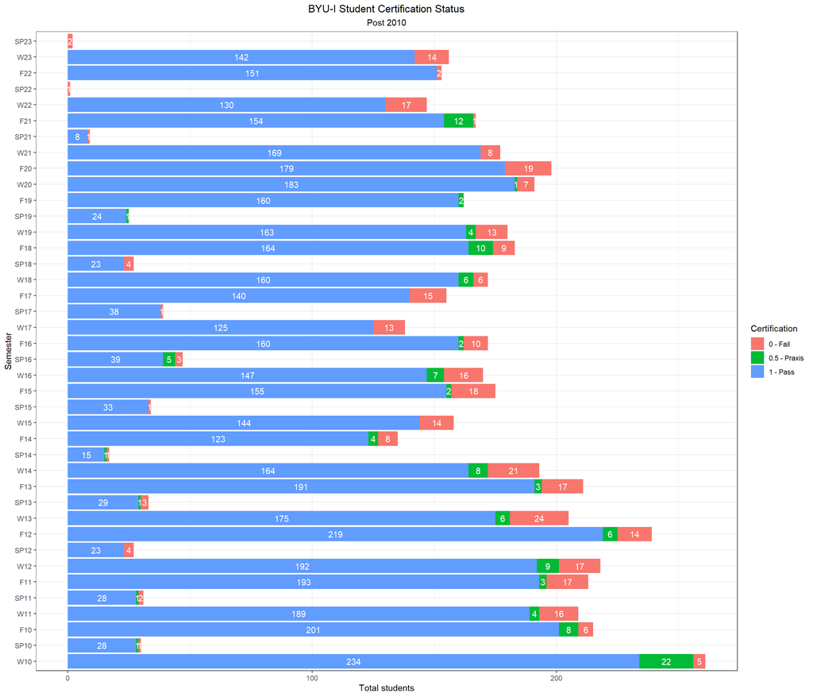

```r
# Graph Findings
data <- df
data$certification <- as.factor(df$certification)

# Remove all entries before 2010
years <- c(  "W03", "SP03", "F03", "W04", "SP04", "SU04", "F04",
             "W05", "SP05", "F05", "W06", "SP06", "F06",
             "W07", "SP07", "F07", "W08", "SP08", "F08",
             "W09", "SP09", "F09")

data <- data |>
  filter(!semester %in% years)

# Create a summary and a visual
data2 <- data |>
  group_by(semester, certification) |>
  summarise(total_students = n())

data2$semester <- factor(data2$semester, levels = c(  "W10", "SP10", "F10",
                                                      "W11", "SP11", "F11",
                                                      "W12", "SP12", "F12",
                                                      "W13", "SP13", "F13",
                                                      "W14", "SP14", "F14",
                                                      "W15", "SP15", "F15",
                                                      "W16", "SP16", "F16",
                                                      "W17", "SP17", "F17",
                                                      "W18", "SP18", "F18",
                                                      "W19", "SP19", "F19",
                                                      "W20", "SP20", "F20",
                                                      "W21", "SP21", "F21",
                                                      "W22", "SP22", "F22",
                                                      "W23", "SP23", "F23"))

# Graph.
ggplot(data2, aes(x = semester, y = total_students, fill = certification, label = total_students))+
  geom_bar(stat = 'identity')+
  geom_text(aes(label=total_students),position = position_stack(0.5), alpha = 1, color = "white")+
  coord_flip() +
  guides(fill = guide_legend(reverse = TRUE)) +
  theme_bw() +
  labs(y = "Total students",
       x = "Semester",
       title = "BYU-I Student Certification Status",
       subtitle = "Post 2010") +
  guides(fill=guide_legend(title="Certification")) +
  scale_fill_discrete(labels=c('0 - Fail', '0.5 - Praxis', '1 - Pass')) +
    theme(
        plot.title = element_text(hjust = 0.5),
        plot.subtitle = element_text(hjust = 0.5))
```